# ETC3250 2019 - Lab 2

Dianne Cook

March 11, 2019

# Class discussion exercises

Textbook questions, chapter 2: 1, 2, 4

1. better performance
2. worse performance
3. better performance
4. worse performance
1. regression and inference
2. classification and prediction
3. regression and prediction
4. Lots of different answers here, try to collect the responses from students
1. spam filters, credit application success, species (animals, plants) labelling,

spam filter: response: ham, spam; predictors: from, subject, words used, …; prediction problem

2. performance in sports, characteristics that lead to exam scores,

performance in sports: response: fatigue; predictors: length of match, number of rallies, score differential, …; probably inference to understand problem, possibly prediction if need to identify players needing interventions

3. grouping stamps, paintings, companies

# Do it yourself

Textbook question 7

```
       Obs.   X1   X2   X3  Distance(0, 0, 0)   Y
       ---------------------------------------------
       1      0    3    0   3                   Red
       2      2    0    0   2                   Red
       3      0    1    3   sqrt(10) ~ 3.2      Red
       4      0    1    2   sqrt(5) ~ 2.2       Green
       5      -1   0    1   sqrt(2) ~ 1.4       Green
       6      1    1    1   sqrt(3) ~ 1.7       Red
```

2. Green. Observation #5 is the closest neighbor for K = 1.
3. Red, because it is the most common of the three responses
4. Red. Observations #2, 5, 6 are the closest neighbors for K = 3. 2 is Red, 5 is Green, and 6 is Red.

# Practice

Complete these exercises by writing your responses into an Rmarkdown document. Give your Rmd file to another group member, outputting to `html` and see if they can `knit` it.

1. Download the chocolates data set, and read into R (recommend using `read_csv` from the `tidyverse` suite).

*About the data:* The chocolates data was compiled by students in a previous class of Prof Cook, by collecting nutrition information on the chocolates as listed on their internet sites. All numbers were normalised to be equivalent to a 100g serving. Units of measurement are listed in the variable name.

```r
library(tidyverse)
choc <- read_csv("http://monba.dicook.org/data/chocolates.csv")
```

2. Take a look at the type of variables in the data. If your question is “How do milk and dark chocolates differ?” what type of problem have you got?

*This is a classification problem.*

3. Compute the means and standard deviations for milk and dark on each of the variables. Make a nice table summary. (Try using the pipe operator, with the wrangling verbs `group_by` and `summarise`, and make the table with the `kableExtra` package.)

```r
library(kableExtra)
choc %>%
  gather(var, value, Calories:Protein_g) %>%
  group_by(Type, var) %>%
  summarise(mean = mean(value), sd = sd(value)) %>%
  arrange(var) %>%
  kable(digits = 1) %>%
  kable_styling(bootstrap_options = "striped", full_width = FALSE)
```

| Type | var | mean | sd |
| --- | --- | --- | --- |
| Dark | CalFat | 356.1 | 65.5 |
| Milk | CalFat | 273.8 | 63.3 |
| Dark | Calories | 550.9 | 62.7 |
| Milk | Calories | 527.0 | 57.6 |
| Dark | Carbs_g | 45.7 | 14.1 |
| Milk | Carbs_g | 57.3 | 8.0 |
| Dark | Chol_mg | 4.5 | 7.4 |
| Milk | Chol_mg | 14.6 | 9.3 |
| Dark | Fiber_g | 7.4 | 3.8 |
| Milk | Fiber_g | 2.3 | 1.8 |
| Dark | Na_mg | 20.2 | 29.1 |
| Milk | Na_mg | 76.5 | 44.5 |
| Dark | Protein_g | 7.5 | 1.9 |
| Milk | Protein_g | 6.7 | 1.4 |
| Dark | SatFat_g | 22.7 | 7.7 |
| Milk | SatFat_g | 18.3 | 5.4 |
| Dark | Sugars_g | 31.1 | 15.0 |
| Milk | Sugars_g | 48.5 | 15.8 |
| Dark | TotFat_g | 40.0 | 7.4 |
| Milk | TotFat_g | 31.5 | 4.3 |

4. Make side-by-side boxplots for each of the variables, for type of chocolate. (Use the grammar of graphics in `ggplot2`.) Write a paragraph explaining how the type of chocolate differs nutritionally.

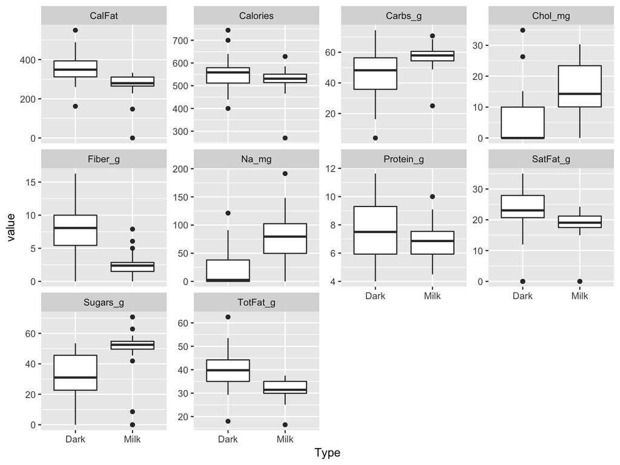

```r
choc %>%
  gather(var, value, Calories:Protein_g) %>%
  ggplot(aes(x = Type, y = value)) +
  geom_boxplot() +
  facet_wrap(~ var, scales = "free_y")
```

*Milk chocolates are generally higher on sugar, cholesterol, sodium (Na) and carbs, but lower in calories from fat, and saturated fat. Dark chocolates tend to have more fibre.*

5. Compute two sample t-tests for each of the variables. Which variable most distinguishes the chocolate type? (This may need to be done using the base R function.)

```r
choc %>%
  gather(var, value, Calories:Protein_g) %>%
  rowid_to_column() %>%
  spread(Type, value) %>%
  group_by(var) %>%
  summarise(p_val = t.test(Dark, Milk)$p.value) %>%
  arrange(p_val)
# # A tibble: 10 x 2
#    var          p_val
#    <chr>        <dbl>
#  1 Fiber_g   1.48e-12
#  2 TotFat_g  1.12e- 9
#  3 Na_mg     6.62e- 8
#  4 CalFat    2.10e- 7
#  5 Chol_mg   2.28e- 6
#  6 Sugars_g  4.10e- 6
#  7 Carbs_g   4.44e- 6
#  8 SatFat_g  2.78e- 3
#  9 Protein_g 2.20e- 2
# 10 Calories  7.44e- 2
```

Fibre is the nutritional item that most distinguishes milk from dark chocolate.